# Cross-Validation

# Introduction

A central problem in machine learning is **model evaluation**: how well does a fitted model predict on *new* data it has never seen? Using the training error for this is misleading — a sufficiently complex model can fit the training data almost perfectly while generalising very poorly.

**Cross-validation (CV)** is a family of resampling techniques that estimate *test* error using only the available data, by repeatedly holding out a portion of it as a proxy for new observations.

We will study three approaches, all illustrated with the `Auto` dataset (fuel consumption of cars):

1. Validation Set Approach
2. Leave-One-Out Cross-Validation (LOOCV)
3. k-Fold Cross-Validation

Throughout, the task is to choose the degree of a polynomial regression of `mpg` on `horsepower`.

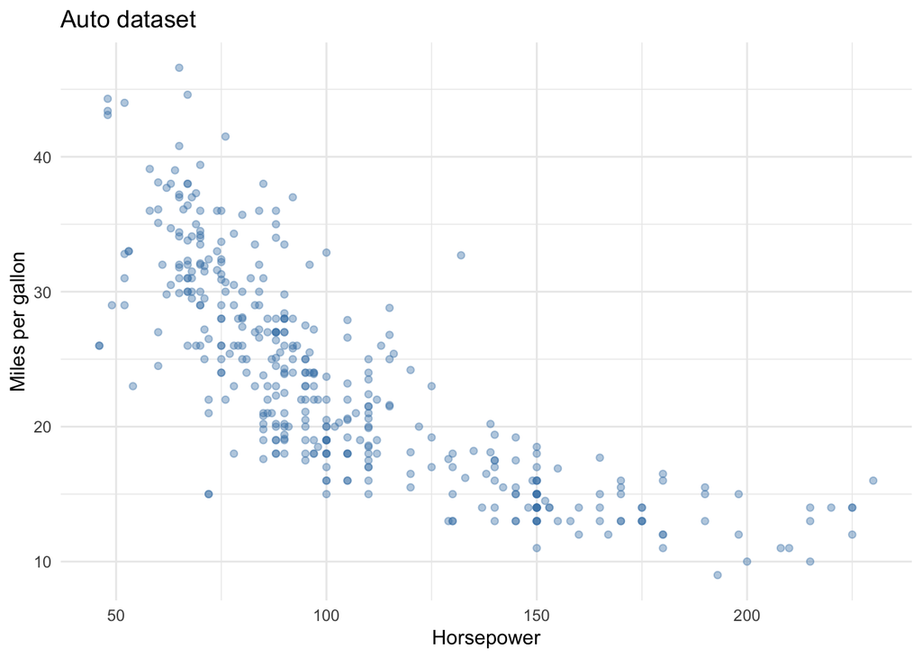

```r
data(Auto)
ggplot(Auto, aes(x = horsepower, y = mpg)) +
  geom_point(alpha = 0.4, colour = "steelblue") +
  labs(title = "Auto dataset", x = "Horsepower", y = "Miles per gallon") +
  theme_minimal()
```

# 1. Validation Set Approach

## 1.1 The idea

Split the data randomly into two disjoint sets:

- **Training set**: used to fit the model.
- **Test set**: used to evaluate it.

The test Mean Squared Error (MSE) is:

$$\text{MSE} = \frac{1}{n_\text{test}}
\sum_{i \in \text{test}} (y_i - \hat{y}_i)^2$$

```r
set.seed(1)
train <- sample(392, 196)   # 50 / 50 split

# Helper: compute test MSE for a model fitted on `train`
mse_function <- function(the_train, the_model) {
  mean((Auto$mpg[-the_train] - predict(the_model, Auto)[-the_train])^2)
}

modelo_1 <- lm(mpg ~ horsepower,           data = Auto, subset = train)
modelo_2 <- lm(mpg ~ poly(horsepower, 2),  data = Auto, subset = train)
modelo_3 <- lm(mpg ~ poly(horsepower, 3),  data = Auto, subset = train)

mse <- c(mse_function(train, modelo_1),
         mse_function(train, modelo_2),
         mse_function(train, modelo_3))
mse
```

```
## [1] 23.26601 18.71646 18.79401
```

The quadratic model clearly improves on the linear one; the cubic adds very little.

Let us also visualise the three fits on the training data:

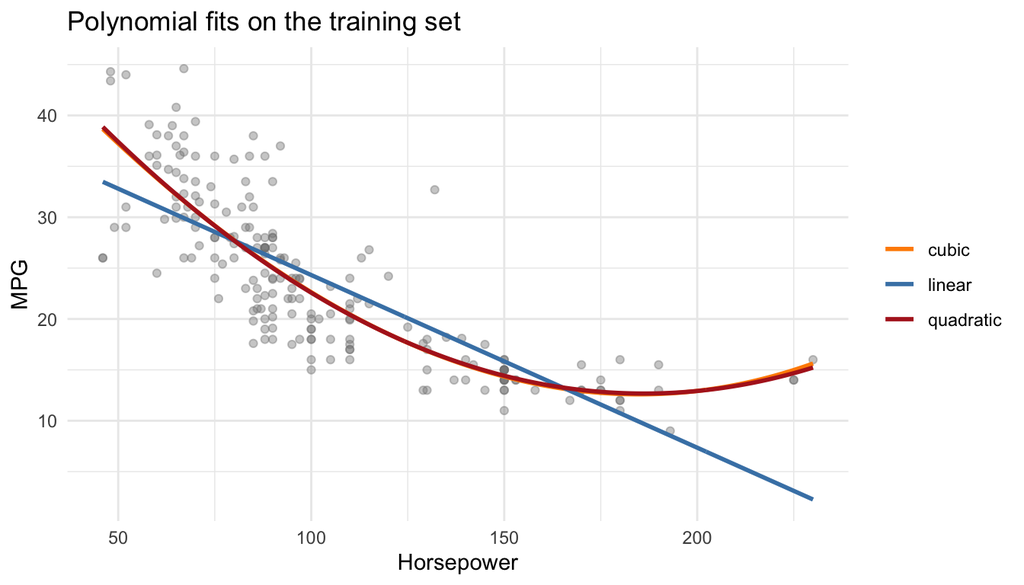

```r
new_data <- data.frame(horsepower = seq(min(Auto$horsepower),
                                        max(Auto$horsepower),
                                        length.out = 300))
new_data$linear    <- predict(modelo_1, newdata = new_data)
new_data$quadratic <- predict(modelo_2, newdata = new_data)
new_data$cubic     <- predict(modelo_3, newdata = new_data)

new_long <- new_data %>%
  pivot_longer(-horsepower, names_to = "Model", values_to = "mpg")

ggplot(Auto[train, ], aes(x = horsepower, y = mpg)) +
  geom_point(alpha = 0.4, colour = "grey50") +
  geom_line(data = new_long, aes(colour = Model), linewidth = 1) +
  scale_colour_manual(values = c(linear = "steelblue",
                                 quadratic = "firebrick",
                                 cubic = "darkorange")) +
  labs(title = "Polynomial fits on the training set",
       x = "Horsepower", y = "MPG", colour = NULL) +
  theme_minimal()
```

## 1.2 Sensitivity to the split

A key weakness of the validation set approach: the estimated test MSE depends heavily on *which* observations end up in the training set. Let us repeat the procedure for 10 different random splits.

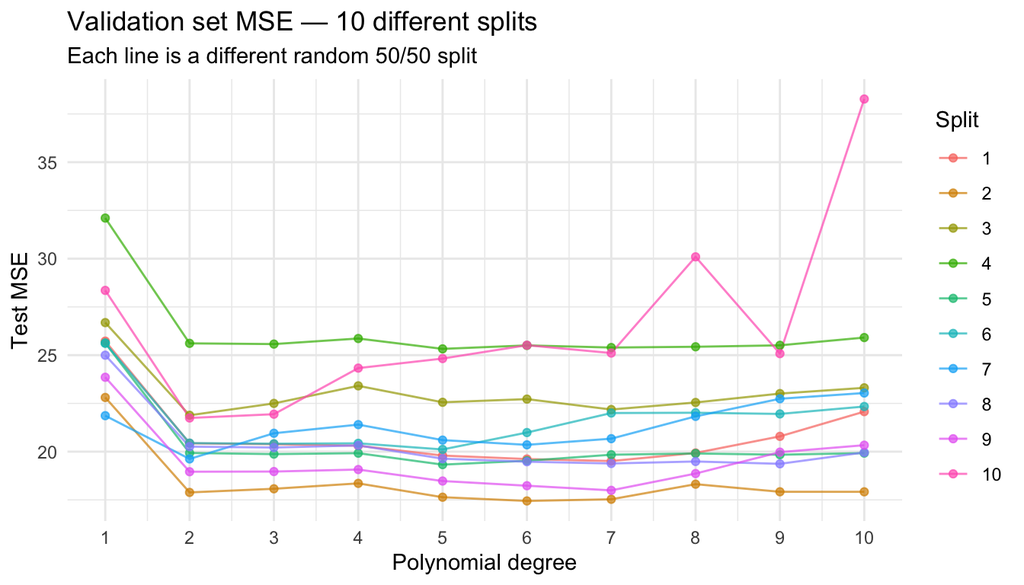

```r
set.seed(2)
results_splits <- lapply(1:10, function(rep) {
  tr <- sample(392, 196)
  mse_vec <- sapply(1:10, function(deg) {
    mod <- lm(mpg ~ poly(horsepower, deg), data = Auto, subset = tr)
    mse_function(tr, mod)
  })
  data.frame(degree = 1:10, MSE = mse_vec, rep = rep)
})

splits_df <- bind_rows(results_splits)

ggplot(splits_df, aes(x = degree, y = MSE,
                      colour = factor(rep), group = factor(rep))) +
  geom_line(alpha = 0.7) +
  geom_point(size = 1.5, alpha = 0.7) +
  scale_x_continuous(breaks = 1:10) +
  labs(title = "Validation set MSE — 10 different splits",
       subtitle = "Each line is a different random 50/50 split",
       x = "Polynomial degree", y = "Test MSE", colour = "Split") +
  theme_minimal()
```

> The curves have the same broad shape (degree 2 is good, higher degrees don’t help much), but the exact values vary considerably. This variability is a major drawback of the validation set approach.

## 1.3 Effect of training set size

More training data generally means a better-fitted model. Here we vary the training proportion from ~50 % to ~90 % for the quadratic model.

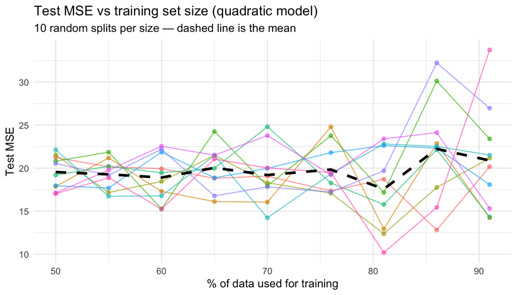

```r
sizes  <- seq(196, 356, by = 20)
n_reps <- 10

size_df <- expand.grid(size = sizes, rep = 1:n_reps) %>%
  rowwise() %>%
  mutate(
    pct_train = round(size / 392 * 100),
    MSE = {
      tr  <- sample(392, size)
      mod <- lm(mpg ~ poly(horsepower, 2), data = Auto, subset = tr)
      mse_function(tr, mod)
    }
  ) %>%
  ungroup()

ggplot(size_df, aes(x = pct_train, y = MSE,
                    colour = factor(rep), group = factor(rep))) +
  geom_line(alpha = 0.6) +
  geom_point(size = 1.5, alpha = 0.6) +
  stat_summary(aes(group = 1), fun = mean, geom = "line",
               colour = "black", linewidth = 1.2, linetype = "dashed") +
  scale_colour_discrete(guide = "none") +
  labs(title = "Test MSE vs training set size (quadratic model)",
       subtitle = paste0(n_reps, " random splits per size — dashed line is the mean"),
       x = "% of data used for training", y = "Test MSE") +
  theme_minimal()
```

# 2. Leave-One-Out Cross-Validation (LOOCV)

## 2.1 The idea

Instead of one big split, we hold out *one observation* at a time:

1. Fit the model on all $n - 1$ remaining observations.
2. Predict the held-out observation; compute $\text{MSE}_i = (y_i - \hat y_i)^2$.
3. Repeat for every $i = 1, \ldots, n$.

The LOOCV estimate is:

$$CV_n = \frac{1}{n} \sum_{i=1}^{n}
\text{MSE}_i$$

This is $k$-fold CV with $k = n$, so it uses almost all the data for training each time. The estimate has **low bias** but can have **high variance** (all $n$ models are very similar, so their errors are correlated).

## 2.2 Manual implementation

```r
n     <- nrow(Auto)
error <- numeric(n)

for (i in 1:n) {
  mod      <- lm(mpg ~ horsepower, data = Auto[-i, ])
  error[i] <- (Auto$mpg[i] - predict(mod, Auto[i, ]))^2
}
cv_loocv <- mean(error)
cv_loocv
```

```
## [1] 24.23151
```

## 2.3 Using the `boot` package

For linear models, `cv.glm()` from `boot` computes LOOCV efficiently (no loop needed):

```r
glm_fit  <- glm(mpg ~ horsepower, data = Auto)
cv_err   <- cv.glm(Auto, glm_fit)
cv_err$delta[1]   # should match manual result above
```

```
## [1] 24.23151
```

`delta[1]` is the raw CV estimate; `delta[2]` is a bias-corrected version (usually very similar).

## 2.4 Polynomial degree comparison

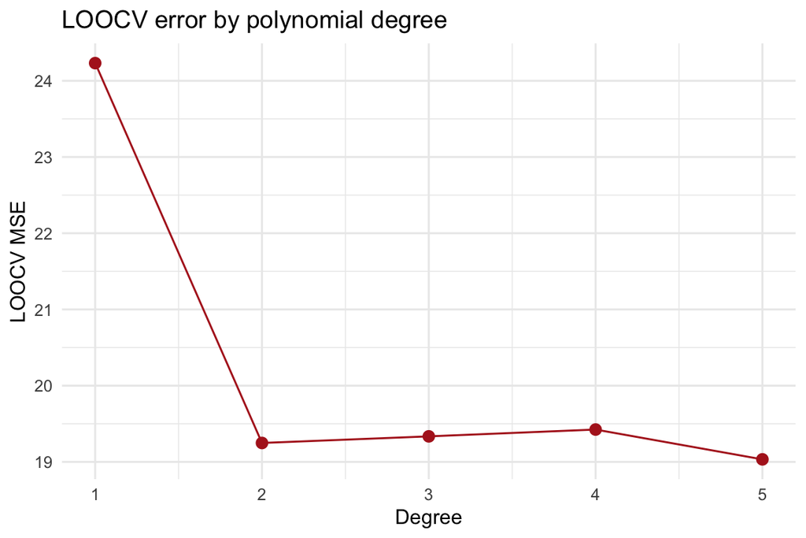

```r
cv_loocv_vec <- sapply(1:5, function(deg) {
  fit <- glm(mpg ~ poly(horsepower, deg), data = Auto)
  cv.glm(Auto, fit)$delta[1]
})

loocv_df <- data.frame(degree = 1:5, CV_MSE = cv_loocv_vec)

ggplot(loocv_df, aes(x = degree, y = CV_MSE)) +
  geom_line(colour = "firebrick") +
  geom_point(colour = "firebrick", size = 2.5) +
  scale_x_continuous(breaks = 1:5) +
  labs(title = "LOOCV error by polynomial degree",
       x = "Degree", y = "LOOCV MSE") +
  theme_minimal()
```

> Again, degree 2 gives the clearest improvement; beyond that the error barely moves. We now have a *much more stable* estimate than the single validation set gave us.

# 3. k-Fold Cross-Validation

## 3.1 The idea

Partition the data into $k$ roughly equal **folds**. For each fold $j$:

1. Train on the other $k - 1$ folds.
2. Test on fold $j$; record $\text{MSE}_j$.

The CV estimate is:

$$CV_k = \frac{1}{k} \sum_{j=1}^{k}
\text{MSE}_j$$

LOOCV is the special case $k = n$. In practice $k = 5$ or $k = 10$ is standard — they produce good estimates at a fraction of the computational cost.

| Method | Bias | Variance | Cost |
| --- | --- | --- | --- |
| Validation set | High | High | Low |
| LOOCV | Low | High | Very high ($n$ models) |
| 10-fold CV | Low–moderate | Low–moderate | Moderate (10 models) |

## 3.2 10-fold CV on polynomial degrees 1–10

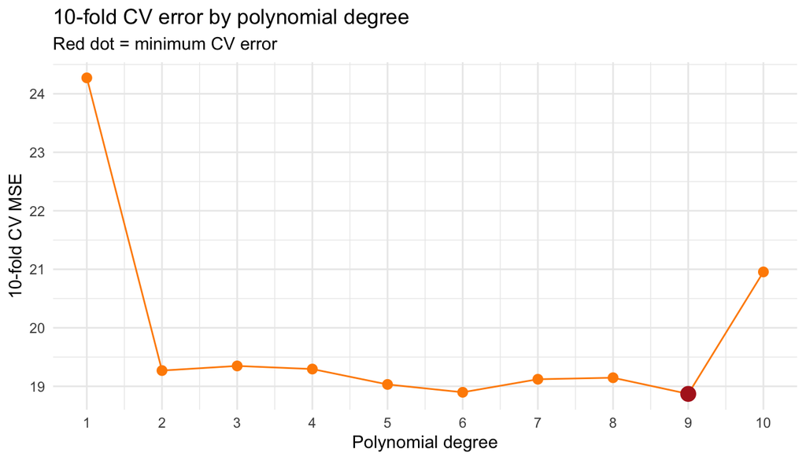

```r
set.seed(17)
cv_10fold <- sapply(1:10, function(deg) {
  fit <- glm(mpg ~ poly(horsepower, deg), data = Auto)
  cv.glm(Auto, fit, K = 10)$delta[1]
})

kfold_df <- data.frame(degree = 1:10, CV_MSE = cv_10fold)

ggplot(kfold_df, aes(x = degree, y = CV_MSE)) +
  geom_line(colour = "darkorange") +
  geom_point(colour = "darkorange", size = 2.5) +
  geom_point(data = kfold_df[which.min(kfold_df$CV_MSE), ],
             colour = "firebrick", size = 4) +
  scale_x_continuous(breaks = 1:10) +
  labs(title = "10-fold CV error by polynomial degree",
       subtitle = "Red dot = minimum CV error",
       x = "Polynomial degree", y = "10-fold CV MSE") +
  theme_minimal()
```

```r
cat("Best degree by 10-fold CV:", which.min(cv_10fold), "\n")
```

```
## Best degree by 10-fold CV: 9
```

```r
kfold_df
```

```
##    degree   CV_MSE
## 1       1 24.27207
## 2       2 19.26909
## 3       3 19.34805
## 4       4 19.29496
## 5       5 19.03198
## 6       6 18.89781
## 7       7 19.12061
## 8       8 19.14666
## 9       9 18.87013
## 10     10 20.95520
```

## 3.3 Comparing all three methods

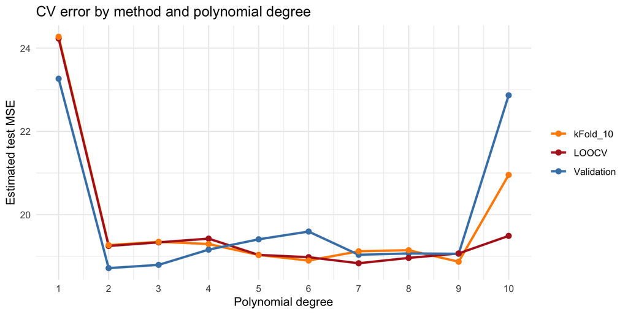

```r
cv_validation <- sapply(1:10, function(deg) {
  set.seed(1)
  tr  <- sample(392, 196)
  mod <- lm(mpg ~ poly(horsepower, deg), data = Auto, subset = tr)
  mse_function(tr, mod)
})

cv_loocv_10 <- sapply(1:10, function(deg) {
  fit <- glm(mpg ~ poly(horsepower, deg), data = Auto)
  cv.glm(Auto, fit)$delta[1]
})

compare_df <- data.frame(
  degree     = 1:10,
  Validation = cv_validation,
  LOOCV      = cv_loocv_10,
  kFold_10   = cv_10fold
) %>%
  pivot_longer(-degree, names_to = "Method", values_to = "CV_MSE")

ggplot(compare_df, aes(x = degree, y = CV_MSE,
                       colour = Method, group = Method)) +
  geom_line(linewidth = 1) +
  geom_point(size = 2) +
  scale_x_continuous(breaks = 1:10) +
  scale_colour_manual(values = c(Validation = "steelblue",
                                 LOOCV      = "firebrick",
                                 kFold_10   = "darkorange")) +
  labs(title = "CV error by method and polynomial degree",
       x = "Polynomial degree", y = "Estimated test MSE", colour = NULL) +
  theme_minimal()
```

> All three methods agree on the main conclusion (degree 2 is sufficient), but LOOCV and 10-fold CV are far more stable than the single validation set.